# AP-4209 ESIEE-Paris: 2024 - 2025

Fouille de données avec R pour la data science et l’intelligence artificielle

III.TD 3 : Partie II - ANALYSE FACTORIELLE DISCRIMINANTE

Badr TAJINI – ESIEE Paris  
Source : Bertrand Roudier – ESIEE Paris

### 1. Introduction

Ce TD a pour objectif de réaliser une analyse factorielle discriminante nous permettant :

- à l’aide d’une diminution de dimentionnalité, de visualiser les données dans le plan des axes facoriels (cf.cours)
- d’effectuer, pour chaque axe, une inférence statistique qui permet de tester la discrimination des différentes classes projetées.

Au total, l’AFD est analogue à une MANOVA, nous permettant de réaliser, de manière concomitante, une visualisation des données.

Pour y parvenir, nous utiliserons le jeu de données *VIN_QUALITE.txt*

### 2. Prés-Requis

- Nous chargeons le fichier *VIN_QUALITE.txt*
- Nous utilisons la fonction que nous avons développée lors du précédant TP pour calculer les sommes des carrés totaux, inter et intra.

```r
rm(list = ls())
library(kableExtra)
library(ggplot2)
library(dplyr)
df <- read.table('VIN_QUALITE.txt', header = T)
```

```r
MANOVA <- function (X,Y)
{
  Xk <- split(X,Y)
  Gk <- lapply(Xk, function(x) sapply(x,mean) )
  G  <-  sapply(X,mean)
  P  <-  ncol(X)
  N  <-  nrow(X)
  Nk <- sapply(Xk, function(x) nrow(x))
  K  <- length(unique(Y))

  mat_G <- matrix(G, nrow = N, ncol = P, byrow = T)
  mat_X <- as.matrix(X)

  SS_Tot <- t(mat_X - mat_G) %*% (mat_X - mat_G)

  SS_partiel_Intra <- lapply(1:K,
            function(x){ delta <- as.matrix(Xk[[x]]) - matrix(Gk[[x]], nrow = nrow(Xk[[x]]), ncol = ncol(Xk[[x]]), byrow = T )
                        t(delta) %*% delta
                      })
  SS_Intra <- matrix(0, ncol = P, nrow = P)
  for (i in 1:K){SS_Intra <- SS_Intra + SS_partiel_Intra[[i]]}

  SS_Inter <- SS_Tot - SS_Intra

  Lam <- det(SS_Intra) / det(SS_Tot)
  V_crit <- -(N - 1 - (P + K)/2) * log(Lam)
  ddl <- P*(K-1)   ; proba <- dchisq( V_crit, ddl)

  ret <- list(
    'SS_tot'   = SS_Tot  ,
    'SS_Intra' = SS_Intra,
    'SS_Inter' = SS_Inter,
    'GK'       = G      ,
    'G'        = G       ,
    'NK'       = Nk      ,
    'P'        = P       ,
    'N'        = N       ,
    'Lambda'   = Lam     ,
    'Proba'    = proba
  )

  return(ret)
}
```

```r
names(df)[5] <- 'Class'
id_num <- which(sapply(df, is.numeric))
X1 <- df[,id_num]
Y1 <- df$Class

# nombre de variables explicatives
N   <- nrow(X1)
k   <- length(unique(Y1))
p   <- ncol(X1)
# pour nommer les axes dans les datas frames
name_axes <- paste0('Axe_', 1: ncol(X1))

res <- MANOVA(X1,Y1)
```

Les résultats sont les suivants:

- La somme des carrés totaux : *SS <sub>Tot</sub>*

```r
res$SS_tot  %>% kbl(digits=3) %>%
       kable_styling(bootstrap_options = "striped", full_width = F, position = "center", latex_options = 'stripped') %>%
       scroll_box( height = "200px")
```

|  | TP | Soleil | Chaleur | Pluie |
| --- | --- | --- | --- | --- |
| TP | 657789.53 | 420250.29 | 40372.294 | -174435.23 |
| Soleil | 420250.29 | 529101.44 | 27056.941 | -180803.85 |
| Chaleur | 40372.29 | 27056.94 | 3310.941 | -12119.35 |
| Pluie | -174435.23 | -180803.85 | -12119.353 | 275690.38 |

- La somme des carrés intra : *SS <sub>Intra</sub>*

```r
res$SS_Intra %>% kbl(digits=3) %>%
       kable_styling(bootstrap_options = "striped", full_width = F, position = "center", latex_options = 'stripped') %>%
       scroll_box( height = "200px")
```

|  | TP | Soleil | Chaleur | Pluie |
| --- | --- | --- | --- | --- |
| TP | 237722.12 | 58284.70 | 14300.939 | 13337.303 |
| Soleil | 58284.70 | 202192.37 | 5245.220 | -4898.030 |
| Chaleur | 14300.94 | 5245.22 | 1664.371 | -1079.515 |
| Pluie | 13337.30 | -4898.03 | -1079.515 | 178499.212 |

- La somme des carrés inter : *SS <sub>Inter</sub>*

```r
res$SS_Inter %>% kbl(digits=3) %>%
       kable_styling(bootstrap_options = "striped", full_width = F, position = "center", latex_options = 'stripped') %>%
       scroll_box( height = "200px")
```

|  | TP | Soleil | Chaleur | Pluie |
| --- | --- | --- | --- | --- |
| TP | 420067.41 | 361965.60 | 26071.35 | -187772.54 |
| Soleil | 361965.60 | 326909.07 | 21811.72 | -175905.82 |
| Chaleur | 26071.35 | 21811.72 | 1646.57 | -11039.84 |
| Pluie | -187772.54 | -175905.82 | -11039.84 | 97191.17 |

### 3. Analyse Factorielle Discriminante

#### 3.1 Rappels

Comme nous l’avons vu en cours, l’analyse factorielle discriminante consiste à trouver une succession d’axes factoriels, tous orthogonaux entre eux et qui maximisent les projections des distances entre les groupes (cf. schéma suivant pour rappel)

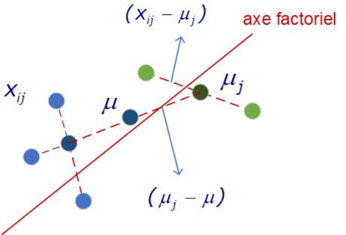

Maximiser les distances entre les groupes revient à maximiser les projections suivantes :

- ${P_1} = {\max _u}\left( {\frac{{{u^t}Bu}}{{{u^t}Wu}}} \right)$ (école Anglo saxonne)

Fort heureusement, les deux méthodes conduisent aux mêmes résultats. Cependant, les approches sont légèrement différentes.

- La méthode anglo-saxonne à un raisonnement analogue à la construction du test d’analyse de variance ou l’on teste le rapport Signal / Bruit (cf. cours page 11). Dans ce cadre, la projection des distances inter groupes est pondérée par les distances intra-groupes
- La méthode française privilégie quant à elle la corrélation canonique c.a.d la part de variation liés au traitement (cf. cours page 11). Dans ce cadre, la projection des distances inter groupes est pondérée par la variation totale

Vous réaliserez une fonction permettant de réaliser une AFD selon la projection *P<sub>1</sub>* (méthode anglo saxonne). Pour y parvenir, nous allons décrire les différentes étapes avec les résultats intermédiaires.

#### 3.2 Diagonalisation

- Nous calculons la matrice du ratio :

  $\frac{B}{W} = \frac{{S{S_{{\rm{inter}}}}}}{{S{S_{{\rm{intra}}}}}} = B \times {W^{ - 1}} = S{S_{{\rm{inter}}}} \times SS_{{\rm{intra}}}^{ - 1}$

Attention la fraction ici correspond à une *division matricielle* et non à une division élément par élément !

Le résultat est le suivant :

```r
SS_total  <- res$SS_tot
SS_inter  <- res$SS_Inter
SS_intra  <- res$SS_Intra
ratio <- SS_inter %*% solve(SS_intra)

ratio %>% kbl(digits=3) %>%
       kable_styling(bootstrap_options = "striped", full_width = F, position = "center", latex_options = 'stripped') %>%
       scroll_box( height = "200px")
```

|  | TP | Soleil | Chaleur | Pluie |
| --- | --- | --- | --- | --- |
| TP | 1.781 | 1.371 | -4.721 | -1.176 |
| Soleil | 1.591 | 1.268 | -5.276 | -1.101 |
| Chaleur | 0.108 | 0.081 | -0.240 | -0.069 |
| Pluie | -0.849 | -0.695 | 3.245 | 0.608 |

Nous calculons maintenant les vecteurs directeurs *u* des axes factoriels et leur coefficient. De manière analogue à l’ACP, la maximisation de
$${P_1} = {\max _u}\left(
{\frac{{{u^t}Bu}}{{{u^t}Wu}}} \right)$$
revient à diagonaliser la matrice $S{S_{{\rm{inter}}}} \times SS_{{\rm{intra}}}^{ - 1}$. Les vecteurs propres correspondent alors aux vecteurs directeurs des axes factoriels. Ces derniers devront être cependant normalisés.
Comme en ACP, les valeurs propres correspondent à la part de dispersion expliquée par chaque axe.

- La diagonalisation est réalisée à l’aide de la fonction *eigen()*
- *remarque importante* : Les algorithmes utilisés peuvent conduire à des matrices de vecteurs propres dont les éléments sont des complexes. *On ne retiendra donc que les parties réels en éliminant les parties complexes* (utiliser la fonction *Re*)

##### 3.2.1 Vecteurs directeurs

- Matrice des vecteurs propres *U*

```r
res_2    <- eigen(ratio)
VectP    <- Re(res_2$vectors)
df_VectP <- data.frame(VectP)
colnames(df_VectP) <- rownames(df_VectP) <- name_axes
df_VectP  %>% kbl(digits=3) %>%
       kable_styling(bootstrap_options = "striped", full_width = F, position = "center", latex_options = 'stripped') %>%
       scroll_box( height = "200px")
```

|  | Axe_1 | Axe_2 | Axe_3 | Axe_4 |
| --- | --- | --- | --- | --- |
| Axe_1 | -0.702 | -0.822 | -0.550 | 0.146 |
| Axe_2 | -0.627 | 0.229 | 0.834 | 0.478 |
| Axe_3 | -0.043 | -0.092 | 0.035 | -0.022 |
| Axe_4 | 0.335 | -0.513 | 0.000 | 0.866 |

Contrairement à l’ACP où nous diagonalisons une matrice symétrique (matrice des variances covariances ou de corrélation), la matrice du ratio *B/W* n’est pas symétrique ce qui conduit à des résultats non exploitables car non normées. Pour y parvenir, nous normalisons la matrice des vecteurs propres :

- Soit *U* la matrice des vecteurs propres: nous calculons *U <sub>Norm</sub>* tel que :

${U_{Norm}} = \frac{U}{{\sqrt {diag({U^t} \times W \times U)} }}$

- la matrice de normalisation (dénominateur) est la suivante :

```r
U   <- VectP
W   <- SS_intra

num <- diag(sqrt(diag(t(U) %*% W %*% U)))

num  %>% kbl(digits=3) %>%
       kable_styling(bootstrap_options = "striped", full_width = F, position = "center", latex_options = 'stripped') %>%
       scroll_box( height = "200px")
```

| 514.758 | 0.000 | 0.000 | 0.000 |
| --- | --- | --- | --- |
| 0.000 | 458.924 | 0.000 | 0.000 |
| 0.000 | 0.000 | 398.689 | 0.000 |
| 0.000 | 0.000 | 0.000 | 438.576 |

- La matrice des vecteurs propres normalisées *Un* est:

```r
Un <- U %*% solve(num)
df_Un <- data.frame(Un) ; colnames(df_Un) <- name_axes

df_Un  %>% kbl(digits=6) %>%
       kable_styling(bootstrap_options = "striped", full_width = F, position = "center", latex_options = 'stripped') %>%
       scroll_box( height = "200px")
```

| Axe_1 | Axe_2 | Axe_3 | Axe_4 |
| --- | --- | --- | --- |
| -0.001364 | -0.001792 | -0.001380 | 0.000332 |
| -0.001218 | 0.000498 | 0.002092 | 0.001091 |
| -0.000083 | -0.000200 | 0.000087 | -0.000050 |
| 0.000650 | -0.001118 | 0.000000 | 0.001974 |

##### 3.2.2 Valeurs propres

- Comme pour les vecteurs propres, nous éliminons la partie imaginaire. les valeurs sont les suivantes:

```r
ValP <- Re(res_2$values)
df_ValP <- data.frame(VP = ValP) ; rownames(df_ValP) <- name_axes

df_ValP  %>% kbl(digits=6) %>%
       kable_styling(bootstrap_options = "striped", full_width = F, position = "center", latex_options = 'stripped') %>%
       scroll_box( height = "200px")
```

|  | VP |
| --- | --- |
| Axe_1 | 3.278860 |
| Axe_2 | 0.138574 |
| Axe_3 | 0.000000 |
| Axe_4 | 0.000000 |

- De manière analogue à l’ACP, les valeurs propres correspondent à la variance expliquée par les axes. Les variances expliquées par les deux derniers axes sont égales à 0. Dans certains cas, les valeur propres peuvent être négatives (ce qui incohérent car il s’agit de variances!) et de très faible valeur (inférieures à 10-7). *Il s’agit d’une erreur de virgule flottante imputable aux calculs itératifs nécessaires à l’estimation des valeurs propres*. Dans ce contexte, on considère ces valeurs comme nulles.
- la part de dispersion expliquée par les axes (inertie des axes) est calculée par l’expression suivante:

${I_i} = \frac{{{\lambda _i}}}{{\sum\limits_i {{\lambda _i}} }}$

Les parts de dispersion sont les suivantes :

```r
Inertie <-  df_ValP / sum(df_ValP) * 100

Inertie  %>% kbl(digits=3) %>%
       kable_styling(bootstrap_options = "striped", full_width = F, position = "center", latex_options = 'stripped') %>%
       scroll_box( height = "200px")
```

|  | VP |
| --- | --- |
| Axe_1 | 95.945 |
| Axe_2 | 4.055 |
| Axe_3 | 0.000 |
| Axe_4 | 0.000 |

Comme on peut le constater, le premier axe explique à lui seul prés de 96 % de la dispersion et le second 4% !.

#### 3.3 Coordonnées des individus

Le calcul des coordonnées des individus sur les axes factoriels (appelées *scores* en anglais) s’effectue en réalisant la projection des observations X **(centrées)** sur les axes factoriels. Les scores sont simplement calculés comme suit :

$Score = Z \times {U_{Norm}}$

Sachant que pour chaque variable *i* de *X* avec ${Z_j} = {X_j} - {{\bar X}_j}$, il suffit donc de multiplier les données centrées *Z* par *Unorm*

Seuls les deux premiers axes factoriels sont à prendre en compte puisqu’ils représentent à eux seul l’intégralité de la dispersion et donc de “l’information contenu dans le tableau initial *Z*”.

Nous créons un data.frame *Scores_df* qui inclue les coordonnées des individus sur les deux premiers axes factoriels ainsi que les différentes classes auxquelles ils appartiennent (variable ‘Class’). On prendra soin de bien vérifier que l’entête de la variable (nom de la variable) soit égale à *‘Class’*

| Axe_1 | Axe_2 | Class |
| --- | --- | --- |
| 0.186 | 0.146 | moyen |
| 0.438 | 0.213 | mauvais |
| 0.164 | -0.088 | moyen |
| 0.508 | -0.124 | mauvais |
| -0.176 | -0.080 | bon |
| -0.407 | 0.022 | bon |
| 0.486 | -0.063 | mauvais |
| 0.405 | 0.159 | mauvais |
| 0.545 | -0.210 | mauvais |
| -0.252 | -0.332 | moyen |
| -0.380 | -0.191 | bon |
| 0.037 | -0.045 | mauvais |
| 0.388 | 0.229 | mauvais |
| -0.287 | -0.050 | bon |
| 0.155 | 0.336 | moyen |
| 0.103 | 0.328 | moyen |
| -0.026 | 0.181 | moyen |
| 0.363 | 0.053 | mauvais |
| -0.162 | -0.142 | moyen |
| -0.401 | -0.123 | bon |
| -0.162 | -0.010 | moyen |
| -0.587 | -0.147 | bon |
| 0.156 | 0.250 | moyen |
| -0.589 | -0.430 | bon |
| 0.014 | 0.110 | moyen |
| -0.777 | -0.329 | bon |
| -0.277 | -0.097 | moyen |
| 0.273 | 0.068 | mauvais |
| -0.374 | -0.065 | bon |
| -0.065 | -0.074 | bon |
| 0.417 | 0.471 | mauvais |
| -0.148 | -0.161 | bon |
| 0.219 | 0.021 | mauvais |
| 0.212 | 0.175 | mauvais |

Nous utilisons la fonction *AFD_graph1* (fournie ci dessous) pour représenter les individus dans le plan factoriel. Les couleurs permettent de différentier les classes. les losanges représentent le centre de gravité des différentes classes

```r
#fonction graphique
AFD_graph1 <- function(Scores, label = T, center = F)
{
  colnames(Scores)[3] <- 'Class'
  print(head(Scores))

  gr <- ggplot()
  if (label == F)
     {
       gr <- gr + geom_point(data = Scores  ,aes(x = Axe_1, y = Axe_2), colour = '#0066CC', size = 1)
     }else
     {
       gr <- gr + geom_point(data = Scores  ,aes(x = Axe_1, y = Axe_2, colour = Class), size = 2)
     }

  if(center == T)
  {
    df_center <- aggregate(Scores[,-3], by = list(Scores$Class ), mean)
    gr <- gr + geom_point(data = df_center, aes(x = Axe_1, y = Axe_2, colour = Group.1 ), shape = 23, size = 2)

  }
  gr <- gr + geom_hline(yintercept = 0 , size = 0.1, colour = 'red') +
             geom_vline(xintercept = 0 , size = 0.1, colour = 'red')
return(gr)
}
```

```
##        Axe_1       Axe_2   Class
## 1  0.1855868  0.14626184   moyen
## 2  0.4381456  0.21271351 mauvais
## 3  0.1643439 -0.08822542   moyen
## 4  0.5077286 -0.12375179 mauvais
## 5 -0.1764461 -0.07990728     bon
## 6 -0.4071447  0.02179057     bon
```

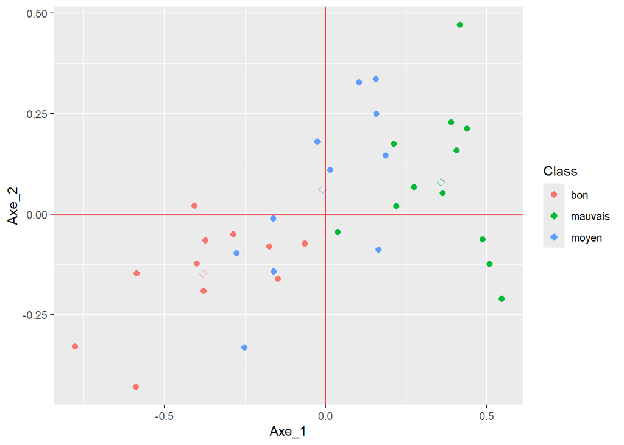

```r
print(AFD_graph1(Scores_df, center = T))
```

#### 3.4 Inférence statistique

Nous effectuons un test de Wilks. En analyse factorielle discriminante, il s’agit de tester successivement le caractère discriminant des axes vis à vis des différentes classes.

Pour y parvenir, nous calculons les corrélations canoniques de chaque axe. Soit $\rho$, la valeur propre associée à chaque axe, la corrélation canonique est :

$${\eta ^2} = \frac{\rho }{{1 + \rho
}}$$

les corrélations canoniques des deux premiers axes sont:

```r
delta2 = sqrt(ValP[1:2] / (1 + ValP[1:2]))
delta2  %>% kbl(digits=3) %>%
       kable_styling(bootstrap_options = "striped", full_width = F, position = "center", latex_options = 'stripped') # %>%
```

| x |
| --- |
| 0.875 |
| 0.349 |

Dans ce TD, nous allons simplifier les hypothèses. Sous Ho, nous posons que les corrélations canoniques des axes factoriels retenus sont égales à zero *versus* H1: au moins une des corrélations différent.

Le test est le suivant:

$$\left\{ \begin{array}{l}
{H_0}:\eta _{{\rm{axe 1}}}^2 = \eta _{{\rm{axe 2}}}^2 = 0\\
{H_1}:{\rm{ }}\eta _{{\rm{axe 1}}}^2{\rm{ et / ou }}\eta _{{\rm{axe
2}}}^2 \ne 0
\end{array} \right.$$

Nous calculons la quantité de Wilks $Wilks = {\Lambda _i} = \prod\limits_{i = 1}^2 {(1 - \lambda _i^2)}$

La quantité suivante suit une distribution de Chi-deux

$$- \left( {n - 1 - \frac{{p + k}}{2}}
\right)\log (\Lambda ) \to \chi _{p(k - 1)ddl}^2$$

avec:

- n: le nombre total d’observations
- p: le nombre de variables
- k: le nombre de classes

Pour les deux premiers axes retenus *(axe_selected = 2)*, L’ensemble des résultats de l’ADF sont résumés dans le tableau :

```r
 axe_selected <- 2
#  N <- nrow(df)
#  p <- ncol(X1)
#  k <- length(res$NK)
result     <- matrix(0, nrow = 2, ncol = 6)
result[,1] <- ValP[1:axe_selected]
result[,2] <- ValP[1:axe_selected]/sum(ValP) *100
result[,3] <- sqrt(ValP[1:axe_selected]/(1+ValP[1:axe_selected]))
result[,4] <- cumprod(1 - result[,3]^2)
result[,5] <- -(N - (p + k)/2 - 1) * log(result[,4])
result[,6] <-  1- pchisq(result[,5],p * (k-1) )


result <- data.frame(result)

colnames(result) <- c('valeur propres',' % inertie','correlation',' Wilks',' Kh Deux','p.value')
result  %>% kbl(digits=3) %>%
       kable_styling(bootstrap_options = "striped", full_width = F, position = "center", latex_options = 'stripped')
```

| valeur propres | % inertie | correlation | Wilks | Kh Deux | p.value |
| --- | --- | --- | --- | --- | --- |
| 3.279 | 95.945 | 0.875 | 0.234 | 42.884 | 0 |
| 0.139 | 4.055 | 0.349 | 0.205 | 46.712 | 0 |

Les résultats précédents montrent que les deux axes discriminent parfaitement les classes (les probas associées à la discrimination sur chaque axe étant proche de zéro). *Attention cela ne prédispose pas de la classification de chaque individus dans les différentes groupes* (ce que nous verrons au prochains TD (TD final)).

### 4. Encapsulation du code

Pour rappel, l’AFD est une méthode de classification supervisée. Le présent TD nous a permis de développer des scripts permettant:

- De calculer les axes factoriels relatives aux projections du compromis B/W
- De positionner les individus dans le plan factoriel ce qui permet de visualiser les positions des individus et des groupes les uns par rapport aux autres
- De tester la qualité de la projection et de la discrimination des groupes sur les axes factoriels

Dans notre exemple, la qualité de discrimination des différents groupes selon les axes est excellente.

Le prochain TD aura pour objectif d’utiliser les coordonnées des observations dans le plan factoriel pour réaliser un classifieur supervisée dont nous testerons la qualité à l’aide d’une matrice des confusions.

Remarque : En cas de *non* discrimination des classes par les axes factoriels (acceptation de Ho et rejet de H1), il est évident qu’il n’est pas possible d’utiliser les projections des individus sur les axes factoriels pour réaliser un classifieur. Dans ce cas, la classification supervisée n’est pas réalisable par cette méthode

Nous créons une fonction générique que nous nommons *AFD*. Les arguments de la fonction sont les suivants :

- AFD <- function(X,Y,SS_tot, SS_intra, SS_inter, nb_axes = 2)
  - X et Y sont respectivement les variables prédictives et Y la variable à prédire
  - SS_tot, SS_intra, SS_inter sont les sommes des carrés calculées à partir de la fonction *MANOVA* que vous avez développée
  - nb_axes est le nombre d’axes sélectionné pour réaliser les projections. Par défaut, il est égal à 2 (projection dans un plan)

Cette fonction retourne une liste dont les éléments sont les suivants (sous forme de data frame):

- les vecteurs propres normalisés (appelés aussi *loading factors* en anglais)
- les valeur propres
- les scores
- le tableau des résultats du test de Wilks

Le data frame des Scores calculés à partir da la fonction *AFD* corresppondent à l’argument de la fonction *AFD_graph1*

Le script final (avec les résultats) doit être le suivant :

```r
AFD <- function(X,Y,SS_tot, SS_intra, SS_inter, nb_axes = 2)
{

N   <- nrow(X)
k   <- length(unique(Y))
p   <- ncol(X)
name_axes <- paste0('Axe_', 1: ncol(X))

ratio <- SS_inter %*% solve(SS_intra)

res_2    <- eigen(ratio)

VectP    <- Re(res_2$vectors)
df_VectP <- data.frame(VectP)
colnames(df_VectP) <- rownames(df_VectP) <- name_axes

U   <- VectP
W   <- SS_intra
num <- diag(sqrt(diag(t(U) %*% W %*% U)))

Un  <- U %*% solve(num)
df_Un <- data.frame(Un) ; colnames(df_Un) <- name_axes

ValP <- Re(res_2$values)
df_ValP <- data.frame(VP = ValP) ; rownames(df_ValP) <- name_axes

Inertie <-  df_ValP / sum(df_ValP) * 100

Z <- scale(X,center = T, scale = F)
Scores <- data.frame(Z %*% Un) ; names(Scores) <-  name_axes
Scores <- Scores[,1:nb_axes]

Scores_df <- data.frame(cbind(Scores, Class = Y))

result     <- matrix(0, nrow = nb_axes, ncol = 6)
result[,1] <- ValP[1:nb_axes]
result[,2] <- ValP[1:nb_axes]/sum(ValP) *100
result[,3] <- sqrt(ValP[1:nb_axes]/(1+ValP[1:nb_axes]))
result[,4] <- cumprod(1 - result[,3]^2)
result[,5] <- -(N - (p + k)/2 - 1) * log(result[,4])
result[,6] <-  1- pchisq(result[,5],p * (k-1) )


result <- data.frame(result)

colnames(result) <- c('valeur propres',' % inertie','correlation',' Wilks',' Kh Deux','p.value')

return(list( Unorm = df_Un,
             Val_P = ValP ,
             Scores = Scores_df,
             Result = result
            ))

}
```

```r
res <- MANOVA(X1,Y1)
afd <- AFD(X1,Y1, res$SS_tot, res$SS_Intra, res$SS_Inter)
gr  <- AFD_graph1(afd$Scores, center = T)
```

```
##        Axe_1       Axe_2   Class
## 1  0.1855868  0.14626184   moyen
## 2  0.4381456  0.21271351 mauvais
## 3  0.1643439 -0.08822542   moyen
## 4  0.5077286 -0.12375179 mauvais
## 5 -0.1764461 -0.07990728     bon
## 6 -0.4071447  0.02179057     bon
```

```r
print(afd)
```

```
## $Unorm
##           Axe_1         Axe_2         Axe_3         Axe_4
## 1 -1.364080e-03 -0.0017915698 -1.380291e-03  3.317987e-04
## 2 -1.218170e-03  0.0004981439  2.092465e-03  1.090719e-03
## 3 -8.279911e-05 -0.0002001082  8.686528e-05 -4.983245e-05
## 4  6.499395e-04 -0.0011181138  6.012951e-08  1.973993e-03
##
## $Val_P
## [1]  3.278860e+00  1.385740e-01  1.251637e-15 -6.366160e-16
##
## $Scores
##          Axe_1       Axe_2   Class
## 1   0.18558675  0.14626184   moyen
## 2   0.43814559  0.21271351 mauvais
## 3   0.16434387 -0.08822542   moyen
```

[output cut: 36 more lines]

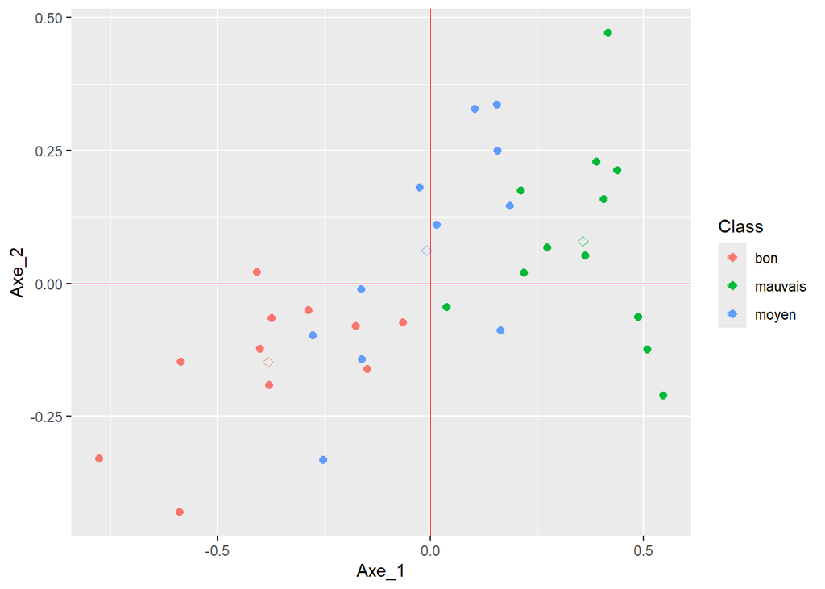

```r
print(gr)
```

### 5. Application

Pour valider votre fonction, vous utiliserez le fichier iris fourni par défaut en R.

Les résultats sont les suivants :

```r
df_iris <- iris
X_iris <- df_iris[,-5]
Y_iris <- df_iris[5]
res_iris <- MANOVA(X_iris,Y_iris)
afd_iris <- AFD(X_iris,Y_iris, res_iris$SS_tot, res_iris$SS_Intra, res_iris$SS_Inter)
gr_iris  <- AFD_graph1(afd_iris$Scores, center = T)
```

```
##      Axe_1      Axe_2  Class
## 1 1.767600 -0.6488697 setosa
## 2 1.782606 -0.6522695 setosa
## 3 1.897096 -0.8174039 setosa
## 4 1.800861 -0.8013811 setosa
## 5 1.796607 -0.7196091 setosa
## 6 1.506379 -0.5789038 setosa
```

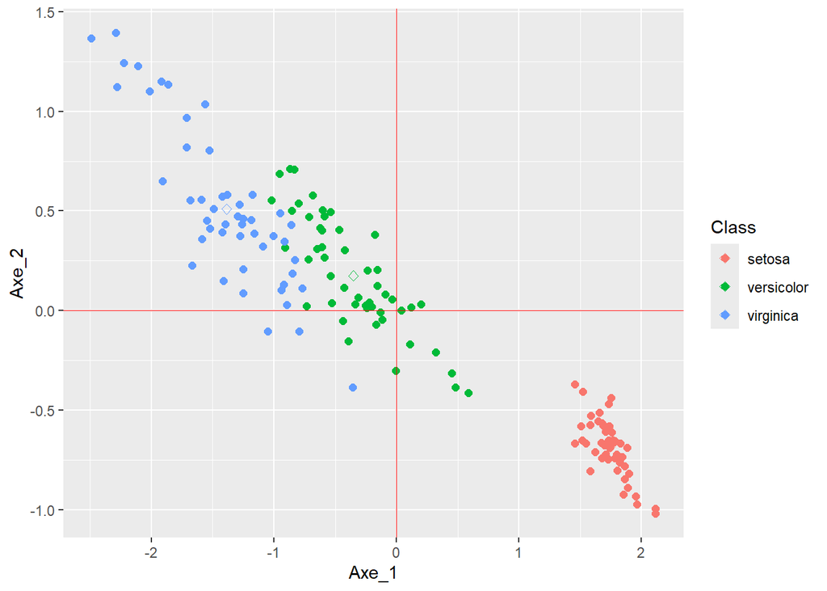

```r
print(gr_iris)
```

- Matrice des vecteurs propres normalisées

```r
afd_iris$Unorm %>% kbl(digits=3) %>%
       kable_styling(bootstrap_options = "striped", full_width = F, position = "center", latex_options = 'stripped') %>%  scroll_box( height = "200px")
```

| Axe_1 | Axe_2 | Axe_3 | Axe_4 |
| --- | --- | --- | --- |
| -0.229 | 0.510 | -0.345 | -0.164 |
| 0.061 | -0.197 | -0.074 | -0.245 |
| -0.565 | 0.237 | 0.068 | -0.032 |
| -0.239 | -0.376 | -0.063 | -0.010 |

```r
afd_iris$Val_P %>% kbl(digits=3) %>%
       kable_styling(bootstrap_options = "striped", full_width = F, position = "center", latex_options = 'stripped') %>%  scroll_box( height = "200px")
```

| x |
| --- |
| 391.683 |
| 13.465 |
| 3.362 |
| 2.123 |

- Scores

```r
afd_iris$Scores %>% kbl(digits=3) %>%
       kable_styling(bootstrap_options = "striped", full_width = F, position = "center", latex_options = 'stripped') %>%  scroll_box( height = "200px")
```

| Axe_1 | Axe_2 | Species |
| --- | --- | --- |
| 1.768 | -0.649 | setosa |
| 1.783 | -0.652 | setosa |
| 1.897 | -0.817 | setosa |
| 1.801 | -0.801 | setosa |
| 1.797 | -0.720 | setosa |
| 1.506 | -0.579 | setosa |
| 1.852 | -0.922 | setosa |
| 1.728 | -0.657 | setosa |
| 1.891 | -0.888 | setosa |
| 1.756 | -0.611 | setosa |
| 1.655 | -0.512 | setosa |
| 1.717 | -0.735 | setosa |
| 1.829 | -0.666 | setosa |
| 2.113 | -0.992 | setosa |
| 1.751 | -0.438 | setosa |
| 1.581 | -0.572 | setosa |
| 1.732 | -0.674 | setosa |
| 1.744 | -0.686 | setosa |
| 1.456 | -0.369 | setosa |
| 1.706 | -0.722 | setosa |
| 1.523 | -0.405 | setosa |
| 1.676 | -0.740 | setosa |
| 2.114 | -1.018 | setosa |
| 1.514 | -0.651 | setosa |
| 1.548 | -0.664 | setosa |
| 1.647 | -0.554 | setosa |
| 1.624 | -0.708 | setosa |
| 1.688 | -0.574 | setosa |
| 1.739 | -0.578 | setosa |
| 1.728 | -0.746 | setosa |

[output cut: 120 more lines]

- Tests MANOVA axes factoriels

```r
afd_iris$Result  %>% kbl(digits=3) %>%
       kable_styling(bootstrap_options = "striped", full_width = F, position = "center", latex_options = 'stripped') %>%  scroll_box( height = "200px")
```

| valeur propres | % inertie | correlation | Wilks | Kh Deux | p.value |
| --- | --- | --- | --- | --- | --- |
| 391.683 | 95.385 | 0.999 | 0.003 | 875.045 | 0 |
| 13.465 | 3.279 | 0.965 | 0.000 | 1266.451 | 0 |

- Si vous trouvez les mêmes résultats c’est que vous avez bien travaillé !